# Por qué llegamos a los cien mil muertos

El fracaso del confinamiento como única herramienta

Daniel Gervini

14 de julio de 2021

Desde principios de la pandemia en marzo del 2020, el gobierno argentino ha usado medidas de confinamiento y restricción de la circulación pública casi como única herramienta para el control de la pandemia. Los resultados están a la vista.

El uso de medidas de confinamiento como herramientas para la lucha contra la pandemia, empezó en China a fines del 2019 y se extendió a Europa a principios del 2020. Pero esos países nunca consideraron tales medidas como la principal herramienta en el combate contra el virus, sino como medidas temporarias de emergencia y de corto plazo, hasta la implementación de sistemas masivos de testeo y rastreo (en el 2020) y campañas de vacunación (en 2021).

En este posteo mostramos que **no hay una relación inequívoca** entre el nivel de movilidad pública y el nivel de circulación del virus, por lo que las medidas de confinamiento *en sí mismas* (es decir, separando lo que aportan otras medidas de distanciamiento social) tuvieron poca efectividad en la Argentina.

En este análisis usamos datos de la ciudad de Buenos Aires, pero los resultados seguramente son similares en otras regiones.

## Movilidad pública y circulación del virus en Buenos Aires

Para medir la movilidad en la ciudad de Buenos Aires, usamos los índices de Google Community Mobility Reports, que pueden encontrarse [acá](https://www.google.com/covid19/mobility/). Estos índices miden la movilidad de la gente en diferentes lugares usando datos del GPS de los celulares. Acá usamos como índice general de movilidad el promedio entre los índices de movilidad en lugares de compras y recreación, y en las estaciones de transporte público:

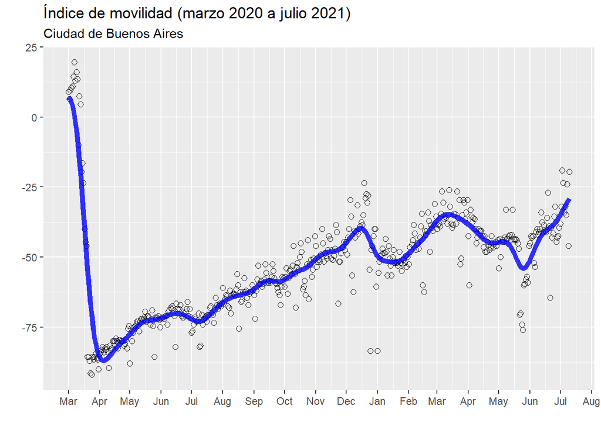

En ese mismo período, la evolución del número de casos diarios fue la siguiente:

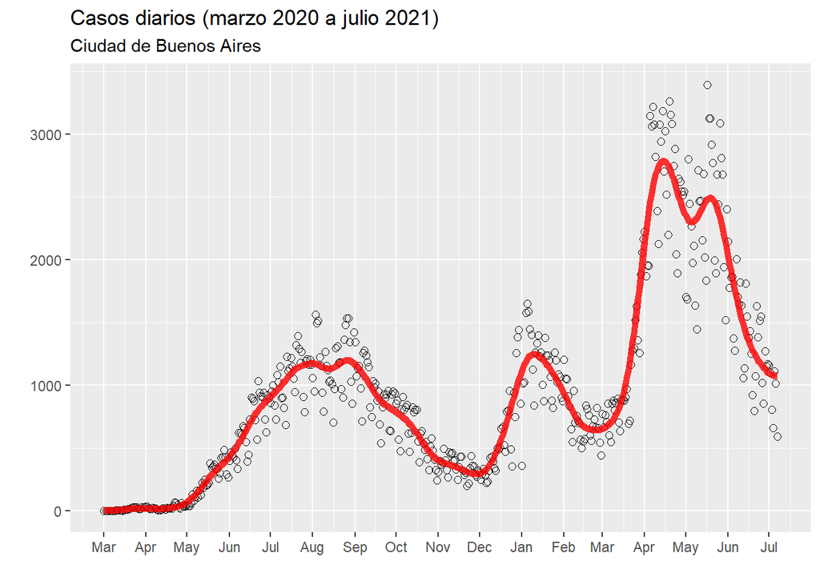

En este gráfico podemos distinguir tres etapas: la *primera ola* hasta el 1 de diciembre de 2020, el *pico de fin de año* entre el 1 de diciembre de 2020 y el 1 de marzo de 2021, y la *segunda ola* a partir del 1 de marzo de 2021.

Ajustando un modelo SIRD a estos datos (para detalles técnicos, ver [este posteo](https://dgervini.github.io/Coronavirus/Technical_details_T2C.html)), se obtiene el número de reproducción básico $R_0$, que determina la evolución de la epidemia y va variando en el tiempo:

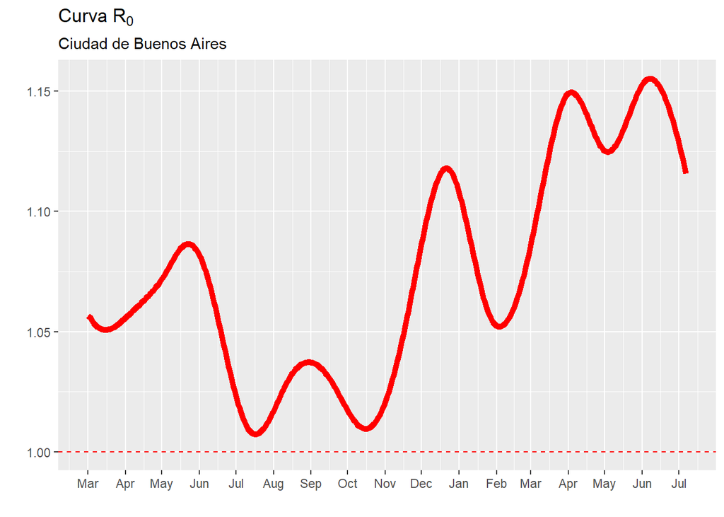

Como vemos, el $R_0$ varió bastante en este período, pero **nunca bajó de 1**. La curva de casos diarios desciende cuando el *número de reproducción efectivo* $R_e$, que es el $R_0$ multiplicado por la proporción de individuos susceptibles en la población, es menor que 1. Como la proporción de individuos susceptibles siempre va bajando con el tiempo, el $R_e$ puede llegar a ser menor que 1 aunque el $R_0$ no lo sea; por eso la curva de contagios diarios a bajado varias veces en estos último meses, aunque el $R_0$ nunca haya bajado de 1.

Se esperaría que las medidas de restricción a la circulación, si fueran efectivas, disminuyeran en algo el $R_0$, aunque no lo hicieran bajar de 1. Pero como muestran los gráficos siguientes, esto no siempre es así. Para ver mejor la relación entre el índice de movilidad y el $R_0$, separamos el análisis en los tres períodos mencionados arriba.

### Primera ola

En este gráfico vemos que el índice de movilidad (línea azul) desciende bruscamente a fines de marzo de 2020 como consecuencia de las primeras medidas de confinamiento estricto, y luego empieza a subir lenta pero continuamente desde abril. El $R_0$ (línea roja), sin embargo, ni desciende bruscamente en marzo y abril, ni sube en paralelo a la movilidad después de abril. El comportamiento del $R_0$ es mayormente independiente de la curva de movilidad.

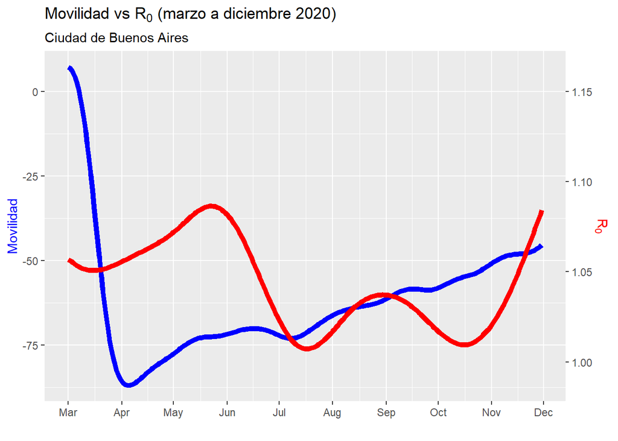

### Pico de fin de año

Entre diciembre de 2020 y marzo de 2021 sí vemos una correlación entre movilidad y $R_0$. Como muestra el siguiente gráfico, un ascenso o descenso en la curva de movilidad fue acompañado de un respectivo ascenso o descenso en el $R_0$ quince días más tarde.

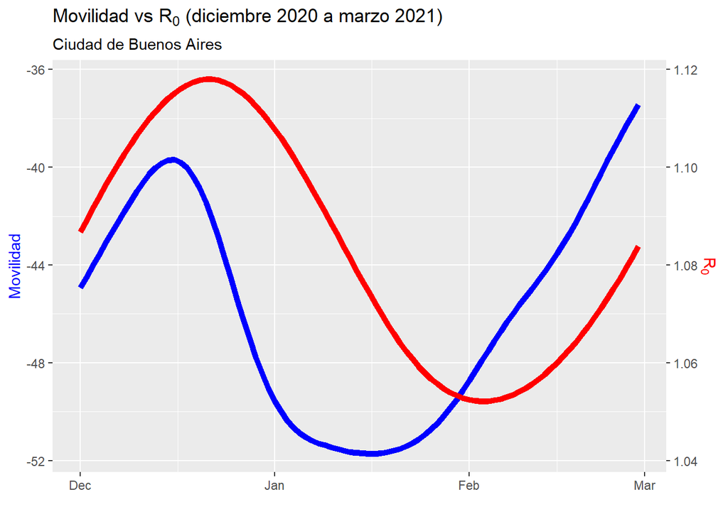

### Segunda ola

A partir de marzo de 2021 vemos nuevamente un desacople entre el índice de movilidad y el $R_0$. La disminución inicial de la movilidad entre marzo y mayo fue acompañada por una disminución del $R_0$, pero luego el $R_0$ empezó a subir aunque la movilidad continuó bajando. El “martillo” de fines de mayo bajó la circulación de manera abrupta, y dos semanas más tarde el $R_0$ alcanzó su valor máximo y empezó a bajar, pero a partir de entonces la movilidad ha aumentado sin pausa mientras que el $R_0$ ha continuado en descenso.

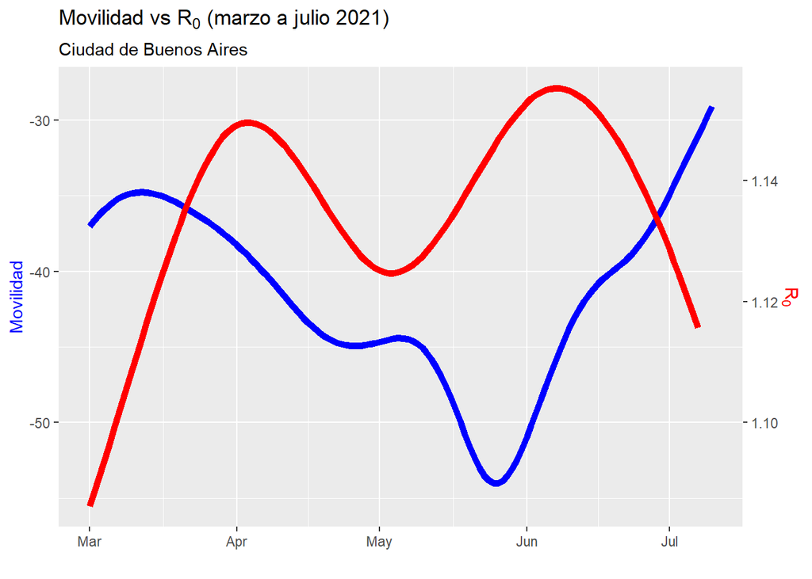

## Conclusiones

Como hemos visto, en los últimos 15 meses no ha habido una relación inequívoca entre el índice de movilidad y el $R_0$. Ni una disminución en la movilidad es necesariamente seguida por una disminución en el $R_0$, ni un aumento en la movilidad es necesariamente seguido por un aumento en el $R_0$. Hay otros factores que influyen en el $R_0$ además de la movilidad. Por eso las medidas de confinamiento como herramienta principal para el control de la pandemia no sirven.

[Back to blog](https://sites.uwm.edu/gervini/coronavirus-blog/)